# Atividade 03

### Algoritmo de *marchine learning*

**Discente:** Danne Makleyston Gomes Pereira  
**Disciplina:** Introdução à Ciência de Dados

```python
import pandas as pd
import numpy as np
from unidecode import unidecode

import matplotlib.cm as cm
import matplotlib.pyplot as plt
%matplotlib inline

import plotly.offline as py
import plotly.graph_objs as go
import plotly.express as px
py.init_notebook_mode(connected=True)

import plotly.graph_objects as go
from plotly.subplots import make_subplots

import seaborn as sns
sns.set(style="ticks", color_codes=True)

from plotnine import ggplot, aes, geom_line, geom_point

from collections import Counter

from sklearn.cluster import KMeans
from sklearn.preprocessing import StandardScaler
from sklearn.decomposition import PCA
from sklearn.metrics import silhouette_samples, silhouette_score
from sklearn.mixture import GaussianMixture
from sklearn.cluster import DBSCAN
from sklearn import metrics

from urllib.request import urlopen, urlretrieve
import json
import warnings

with urlopen('https://raw.githubusercontent.com/tbrugz/geodata-br/master/geojson/geojs-23-mun.json') as response:
    cities_json_ = json.load(response)

for i in range(len(cities_json_['features'])):
    cities_json_['features'][i]['properties']['name'] = unidecode(cities_json_['features'][i]['properties']['name'].upper())
```

# Carregando dados

Vamos iniciar nosso trabalho carregando os dados socioeconômicos referentes às cidades do Ceará. A base de dados utilizada pode ser encontrada nesse link [*Dataset* Brazilian Cities](https://www.kaggle.com/crisparada/brazilian-cities).

Foi necessário realizar alguns tratamentos no nomes das colunas, pois havia muitos caracteres indesejados e não havia um padrão entre *upper case* e *lower case*.

```python
df_brasilian_cities = pd.read_csv('BRAZIL_CITIES.csv', sep=';', lineterminator='\n')
columns = [x.lower().strip().replace('-','').replace(' ','_') for x in df_brasilian_cities.columns.values]
df_brasilian_cities.columns = columns
```

Apenas alguns campos foram importados, pois muitos não contemplavam a necessidade desse trabalho e/ou não possuíam dados suficientes.

```python
df_brasilian_cities = df_brasilian_cities[['city', 'state', 'ibge_res_pop',
                                           'ibge_1559', 'idhm', 'lat', 'long',
                                           'idhm_renda', 'idhm_educacao', 'gdp_capita',
                                           'comp_b', 'comp_c', 'comp_e', 'comp_f',
                                           'comp_g', 'comp_h', 'comp_i', 'comp_j', 'comp_k', 'comp_l',
                                           'comp_m', 'comp_n', 'comp_p', 'comp_q', 'comp_r', 'comp_s']]
```

Para possibilitar *merges* entre *datasets* pelo campo *city* é necessário que os campos possuam o mesmo padrão.  
Optamos por deixá-los tudo maiúsculo e sem acento.

```python
df_brasilian_cities['city'] = df_brasilian_cities['city'].apply(lambda d: unidecode(d.upper()) if d is not np.nan else d)
df_brasilian_cities['state'] = df_brasilian_cities['state'].apply(lambda d: d.upper())
```

```python
df_ce_cities = df_brasilian_cities[df_brasilian_cities['state'] == 'CE'].copy()
```

```python
drop_columns = ['state']
```

```python
df_ce_cities.drop(columns = drop_columns, inplace = True)
df_ce_cities.reset_index(drop = True, inplace = True)
```

```python
columns_dict = {'comp_b':'Extractive', 'comp_c':'Transformation','comp_e':'Water', 'comp_f':'Construction',
                'comp_g':'Repair of motor vehicles ', 'comp_h':'Transport, storage and mail','comp_i':'Accommodation and food',
                'comp_j':'Information and communication','comp_k':'Financial, insurance', 'comp_l':'Real estate activities',
                'comp_m':'Professional, scientific and technical activities', 'comp_n':'Administrative activities','comp_p':'Education',
                'comp_q':'Human health and social services','comp_r':'Arts, culture, sport and recreation', 'comp_s':'Other service activities'}
```

```python
df_ce_cities_adjusted = df_ce_cities.copy()
```

```python
for col in list(columns_dict.keys()):
    df_ce_cities_adjusted[col] = round(df_ce_cities[col] * 100000 / df_ce_cities['ibge_res_pop'], 2)

df_ce_cities_adjusted['ibge_1559'] = round((df_ce_cities['ibge_1559'] / df_ce_cities['ibge_res_pop']) * 100, 2)
```

```python
df_ce_cities_adjusted['idhm'] = df_ce_cities_adjusted['idhm'].apply(lambda d: round(d, 2) * 100)
df_ce_cities_adjusted['idhm_renda'] = df_ce_cities_adjusted['idhm_renda'].apply(lambda d: round(d, 2) * 100)
df_ce_cities_adjusted['idhm_educacao'] = df_ce_cities_adjusted['idhm_educacao'].apply(lambda d: round(d, 2) * 100)
```

```python
df_ce_cities_adjusted.drop(columns = ['city', 'lat', 'long', 'ibge_res_pop', 'gdp_capita'], inplace = True)
```

```python
df_ce_cities_adjusted.shape
```

```
(184, 20)
```

```python
for col in list(columns_dict.keys()):
    print(col, df_ce_cities_adjusted[df_ce_cities_adjusted[col] == 0][col].count())
```

```
comp_b 109
comp_c 5
comp_e 110
comp_f 22
comp_g 0
comp_h 46
comp_i 23
comp_j 46
comp_k 127
comp_l 106
comp_m 11
comp_n 5
comp_p 12
comp_q 36
comp_r 53
comp_s 0
```

```python
columns_drop = ['comp_b', 'comp_e', 'comp_k', 'comp_l']
df_ce_cities_adjusted_fix = df_ce_cities_adjusted.iloc[:,~df_ce_cities_adjusted.columns.isin(columns_drop)]
```

```python
X = df_ce_cities_adjusted_fix.values
y = df_ce_cities['ibge_res_pop'].values
```

### PCA

```python
X_std = StandardScaler().fit_transform(X)
```

```python
pca = PCA().fit(X_std)
variances = np.cumsum(pca.explained_variance_ratio_)
ticks = np.arange(1, X.shape[1]+1, step=1)
fig = px.line(x=ticks, y=variances, title='PCA')
fig.show()
```

[interactive chart not shown]

```python
_n_comp_PCA = 12

pca = PCA(_n_comp_PCA)
X_comps = pca.fit_transform(X_std)
```

### DBSCAN

```python
np.arange(1,3, 1)
```

```
array([1, 2])
```

```python
def DBSCAN_check(max_eps, max_samples, _X):
    for i in np.arange(2, max_eps + 0.5, 0.5):
        n_clusters_ = list()
        n_noise_ = list()
        silhouette_score_ = list()

        for j in range(2, max_samples):
            dbscan = DBSCAN(eps=i, min_samples=j, metric='euclidean')
            model = dbscan.fit(_X)
            labels = model.labels_
            n_clusters_ .append(len(set(labels)) - (1 if -1 in labels else 0))
            n_noise_.append(list(labels).count(-1))
            silhouette_score_.append(round(silhouette_score(_X, labels)*100, 2))

        _xaxes = np.arange(1, max_samples, 1)

        trace_n_clusters = go.Scatter(x=_xaxes, y=n_clusters_, mode='lines', name='n_clusters')
        trace_n_noise = go.Scatter(x=_xaxes, y=n_noise_, mode='lines', name='n_noise')
        trace_silhouette_score = go.Scatter(x=_xaxes, y=silhouette_score_, mode='lines', name='silhouette_score')

        fig = go.Figure()
        fig.add_trace(trace_n_clusters)
        fig.add_trace(trace_n_noise)
        fig.add_trace(trace_silhouette_score)
        fig.update_layout(title='Evolução do ruído (EPS: '+str(i)+')',
                   xaxis_title='Número de nós por cluster',
                   yaxis_title='Quantidade')

        fig.show()

cluster_labels = DBSCAN_check(3, 10, X_std)
```

[interactive chart not shown]

### Gaussian Mixture Model

```python
def GMM_k_check(range_n_clusters, _X):
    for n_clusters in range_n_clusters:
        clusterer = GaussianMixture(n_components=n_clusters)
        clusterer.fit(_X)
        cluster_labels = clusterer.predict(_X)
        silhouette_avg = silhouette_score(_X, cluster_labels)
        print("For n_clusters =", n_clusters,
              "The average silhouette_score is :", silhouette_avg)

range_n_clusters = [2, 3, 4, 5, 6, 7, 8]
print('\n **** X_comps ****')
GMM_k_check(range_n_clusters, X_comps)
# print('\n **** X_std ****')
# GMM_k_check(range_n_clusters, X_std)
print('\n **** X ****')
GMM_k_check(range_n_clusters, X)
```

```
 **** X_comps ****
For n_clusters = 2 The average silhouette_score is : 0.38833788198831143
For n_clusters = 3 The average silhouette_score is : 0.3426748223590512
For n_clusters = 4 The average silhouette_score is : 0.15735327602011417
For n_clusters = 5 The average silhouette_score is : 0.07155534193393595
For n_clusters = 6 The average silhouette_score is : 0.12811756117902887
For n_clusters = 7 The average silhouette_score is : 0.10571632603721488
For n_clusters = 8 The average silhouette_score is : 0.08773555545817086

 **** X ****
For n_clusters = 2 The average silhouette_score is : 0.3478332604066614
For n_clusters = 3 The average silhouette_score is : 0.1656943817556912
For n_clusters = 4 The average silhouette_score is : 0.11598826809857286
For n_clusters = 5 The average silhouette_score is : 0.08047702106956933
For n_clusters = 6 The average silhouette_score is : 0.18626961995905372
For n_clusters = 7 The average silhouette_score is : 0.12262839802335963
For n_clusters = 8 The average silhouette_score is : 0.15456771085801205
```

```python
_n_clusters = 2
```

```python
GMM = GaussianMixture(n_components=_n_clusters)
GMM.fit(X)
cluster_labels = GMM.predict(X)
cluster_labels
```

```
array([0, 0, 0, 0, 0, 0, 0, 1, 0, 0, 0, 1, 1, 0, 0, 0, 0, 0, 0, 0, 0, 0,
       1, 0, 0, 0, 0, 0, 0, 0, 1, 0, 0, 0, 0, 0, 0, 0, 0, 0, 0, 0, 0, 1,
       0, 0, 0, 0, 0, 0, 1, 0, 1, 0, 0, 1, 0, 0, 1, 0, 1, 0, 0, 0, 0, 1,
       0, 0, 1, 0, 0, 0, 0, 0, 1, 0, 1, 0, 0, 0, 0, 0, 0, 0, 0, 1, 0, 0,
       0, 0, 0, 0, 0, 1, 0, 0, 1, 1, 1, 0, 0, 1, 0, 0, 0, 1, 0, 0, 0, 0,
       0, 0, 0, 0, 0, 0, 1, 0, 0, 0, 0, 0, 0, 0, 0, 0, 0, 0, 0, 1, 0, 0,
       0, 0, 0, 0, 0, 1, 0, 0, 0, 0, 0, 0, 0, 0, 0, 0, 0, 0, 0, 0, 0, 0,
       0, 0, 0, 0, 0, 0, 0, 1, 1, 0, 0, 0, 1, 0, 1, 0, 0, 0, 0, 1, 0, 0,
       0, 0, 0, 0, 0, 0, 0, 0])
```

```python
Counter(cluster_labels)
```

```
Counter({0: 154, 1: 30})
```

### K-means++

#### Método do cotovelo - Usando X

```python
EQM = []

for i in range(1, len(df_ce_cities_adjusted.columns)):
    kmeans = KMeans(n_clusters = i, init = 'k-means++', random_state = 0)
    kmeans.fit(X)
    EQM.append(kmeans.inertia_)

fig = px.line(x=range(1,len(df_ce_cities_adjusted.columns)), y=EQM, title='Gráfico - Método do "cotovelo"')
fig.show()
```

[interactive chart not shown]

#### Método do cotovelo - Usando PCA

```python
EQM = []

for i in range(1, len(df_ce_cities_adjusted.columns)):
    kmeans = KMeans(n_clusters = i, init = 'k-means++', random_state = 0)
    kmeans.fit(X_comps)
    EQM.append(kmeans.inertia_)

fig = px.line(x=range(1,len(df_ce_cities_adjusted.columns)), y=EQM, title='Gráfico - Método do "cotovelo"')
fig.show()
```

[interactive chart not shown]

### Validando a quantidade de *clusters*

```python
def KMEANS_k_check(range_n_clusters, _X):
    for n_clusters in range_n_clusters:

        clusterer = KMeans(n_clusters=n_clusters, random_state=10)
        cluster_labels = clusterer.fit_predict(_X)

        silhouette_avg = silhouette_score(_X, cluster_labels)
        print("For n_clusters =", n_clusters,
              "The average silhouette_score is :", silhouette_avg)

range_n_clusters = [2, 3, 4, 5, 6, 7, 8]
print('\n **** X_comps ****')
KMEANS_k_check(range_n_clusters, X_comps)
# print('\n **** X_std ****')
# KMEANS_k_check(range_n_clusters, X_std)
print('\n **** X ****')
KMEANS_k_check(range_n_clusters, X)
```

```
 **** X_comps ****
For n_clusters = 2 The average silhouette_score is : 0.8293859648365135
For n_clusters = 3 The average silhouette_score is : 0.3490487859102799
For n_clusters = 4 The average silhouette_score is : 0.13291010716990848
For n_clusters = 5 The average silhouette_score is : 0.1594798505157223
For n_clusters = 6 The average silhouette_score is : 0.1646944296007727
For n_clusters = 7 The average silhouette_score is : 0.15618950468666104
For n_clusters = 8 The average silhouette_score is : 0.14650631316635132

 **** X ****
For n_clusters = 2 The average silhouette_score is : 0.4396550871240926
For n_clusters = 3 The average silhouette_score is : 0.3560359656986341
For n_clusters = 4 The average silhouette_score is : 0.27502910307039136
For n_clusters = 5 The average silhouette_score is : 0.2861941942808957
For n_clusters = 6 The average silhouette_score is : 0.30944005940276226
For n_clusters = 7 The average silhouette_score is : 0.30041661995439944
For n_clusters = 8 The average silhouette_score is : 0.3038807267730551
```

**Resultado com PCA 12 e sem a cidade Eusébio**  
For n_clusters = 2 The average silhouette_score is : 0.3577585287235601  
For n_clusters = 3 The average silhouette_score is : 0.1654645607912345  
For n_clusters = 4 The average silhouette_score is : 0.171233095082678  
For n_clusters = 5 The average silhouette_score is : 0.16464362070871014  
For n_clusters = 6 The average silhouette_score is : 0.1370109568361509  
For n_clusters = 7 The average silhouette_score is : 0.1407149740833062  
For n_clusters = 8 The average silhouette_score is : 0.13502092760398696

```python
_n_clusters = 2
```

```python
k_clusters = KMeans(n_clusters = _n_clusters, random_state = 0)
cluster_labels = k_clusters.fit_predict(X)
print(cluster_labels)
```

```
[0 0 0 0 0 0 0 0 0 0 0 0 1 0 0 0 0 0 0 0 0 0 0 0 0 1 1 0 0 0 1 0 1 1 0 0 0
 0 0 0 1 0 1 0 0 0 0 0 0 1 1 0 1 0 0 1 0 0 1 0 1 0 0 0 0 1 0 1 1 0 0 0 0 0
 1 0 1 1 0 0 1 0 1 0 0 0 0 0 0 0 0 0 0 1 1 0 0 1 1 0 0 1 0 1 0 1 0 0 0 0 0
 0 0 0 1 0 0 0 0 0 0 1 0 0 0 1 0 0 0 1 0 0 0 1 0 0 0 1 0 0 1 0 0 0 1 0 0 0
 0 0 0 0 0 1 1 0 0 1 0 0 1 0 1 0 0 0 1 1 1 0 0 1 0 1 0 0 0 0 0 0 0 1 0 0]
```

```python
Counter(cluster_labels)
```

```
Counter({0: 136, 1: 48})
```

### Conhecendo as cidades de cada grupo

```python
df_ce_cities_adjusted['group'] = cluster_labels
df_ce_cities['group'] = cluster_labels
```

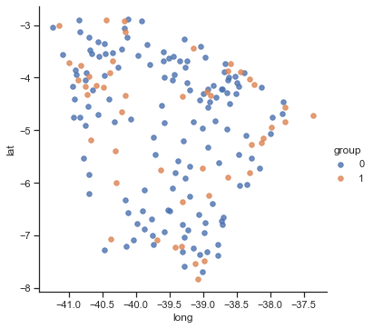

```python
lat = df_ce_cities["lat"] != 0
long = df_ce_cities["long"] != 0

_df = df_ce_cities.copy()
_df['group'] = cluster_labels

sns.lmplot(data=_df[lat&long], x="long", y="lat",
           fit_reg=False, hue='group', legend=True, scatter_kws={"s": 30},
           height=5)
```

```python
def group_map(data):
    colorscales = px.colors.named_colorscales()
    fig = px.choropleth_mapbox(data, geojson=cities_json_, locations='city', color='group',
                               color_continuous_scale = ['#7ed6df', '#f9ca24', '#686de0', '#ff7979', "#badc58", "#535c68"],
                               featureidkey="properties.name",
                               mapbox_style="carto-positron",
                               zoom=6, center = {"lat": -5.1814679, "lon": -39.2140467},
                               opacity=1,
                               title='Mapa do Ceará clusterizado'
                              )
    fig.update_layout(coloraxis_colorbar=dict(
                        title="Grupos",
                        thicknessmode="pixels", thickness=50,
                        yanchor="top", y=1,
                        ticks="outside",
                        dtick=1
                    ))
    return fig.show()
group_map(df_ce_cities)
```

[interactive chart not shown]

### Comparação entre *clusters*

```python
def show(data):
    _data = data.groupby(by=['group']).mean()
    _index = list(_data.index)

    traces = []
    for col in list(columns_dict.keys()):
        traces.append(go.Bar(x = _index, y = _data.loc[:,col], name=columns_dict[col][:15]))

    fig = go.Figure(traces)
    fig.update_layout(title = 'Média das CIA por grupo (quantidade de CIA por 100.000 habitantes)')
    fig.show()

show(df_ce_cities)
```

[interactive chart not shown]

### Conhecendo os *clusters*

```python
def show_group(data):

    avg = data['idhm'].mean()
    fig = px.bar(data, x='city', y='idhm')

    fig.add_shape(type="line", xref="paper", x0=0, y0=avg, x1=1, y1=avg,
                    line=dict(color="magenta", width=3))

    trace1 = go.Pie(labels = ['IDHM', 'IDHM Renda', 'IDHM Educação'],
               values = [data['idhm'].mean(), data['idhm_renda'].mean(), data['idhm_educacao'].mean()], hole=.3)
    trace2 = go.Pie(labels = [columns_dict[c][:20] for c in list(columns_dict.keys())],
                    values= [data[c].mean() for c in list(columns_dict.keys())], hole=.3)

    fig_sub = make_subplots(rows=1, cols=2, specs=[[{'type':'domain'}, {'type':'domain'}]])
    fig_sub.add_trace(trace1, 1, 1)
    fig_sub.add_trace(trace2, 1, 2)

    fig.update_layout(
        title='Cidades do "Grupo '+str(data['group'].max())+'" - AVG IDHM '+str(round(avg, 3)),
        height=500,
        margin=dict(l=50,r=50,b=0,t=50,pad=4)
    )

    fig_sub.update_layout(
        height=500,
        margin=dict(l=50,r=50,b=0,t=0,pad=4)
    )
    fig_sub.update_traces(hoverinfo='label+percent', textinfo='value')

    fig.show()
    fig_sub.show()

show_group(df_ce_cities[df_ce_cities['group'] == 0])
```

[interactive chart not shown]

```python
show_group(df_ce_cities[df_ce_cities['group'] == 1])
```

[interactive chart not shown]

```python
# show_group(df_ce_cities[df_ce_cities['group'] == 2])
```

### Comparação com quantidade de projetos aprovados por cidade

```python
df_secult = pd.read_csv('dt.csv', sep='\t', lineterminator='\n')
```

```python
df_secult['amount_registers'] = df_secult['amount_registers'].apply(lambda d: int(np.nan_to_num(d)))
df_secult['city'] = df_secult['city'].apply(lambda d: d.upper() if d is not np.nan else d)
df_secult['project_title'] = df_secult['project_title'].apply(lambda d: d.upper() if d is not np.nan else d)
df_secult['title'] = df_secult['title'].apply(lambda d: d.upper() if d is not np.nan else d)
df_secult['bidder'] = df_secult['bidder'].apply(lambda d: d.upper() if d is not np.nan else d)
df_secult['city'] = df_secult['city'].apply(lambda d: unidecode(d) if d is not np.nan else d)
df_secult['registration_date_init'] = pd.to_datetime( df_secult['registration_date_init'] )
df_secult['registration_date_end'] = pd.to_datetime( df_secult['registration_date_end'] )
```

```python
df_secult.drop(['categories', 'order'], axis=1, inplace=True)
df_secult['value'].fillna(0., inplace=True)
df_secult = df_secult[~df_secult['city'].isna()]
df_secult.reset_index(drop=True, inplace=True)
```

```python
tmp = df_secult.groupby(by=['city']).count()
df_notice_cities = pd.DataFrame({'city': tmp.index, 'number_of_approved_project':tmp['value'].values})
df_notice_cities.head()
# df_notice_cities[df_notice_cities['city'] == 'EUSEBIO'].head()
```

|  | city | number_of_approved_project |
| --- | --- | --- |
| 0 | ABAIARA | 2 |
| 1 | ACARAPE | 2 |
| 2 | ACARAU | 8 |
| 3 | ACOPIARA | 10 |
| 4 | AIUABA | 2 |

```python
df_full = pd.merge(df_ce_cities, df_notice_cities, left_on='city', right_on='city')
```

```python
_pop_by_group = []
for i in range(0, _n_clusters):
    _pop_by_group.append(df_ce_cities[cluster_labels == i]['ibge_res_pop'].sum())
```

```python
_pop_by_group
```

```
[3797212.0, 4655169.0]
```

```python
def show_approved_projects(data):
    _data = data.groupby(by=['group'])['number_of_approved_project'].sum()

    fig = make_subplots(rows=1, cols=2, subplot_titles=['Quantidade de projetos aprovados por grupo', 'Quantidade de projetos aprovadospor 100.000 h.'])
    trace1 = go.Bar(x = _data.index.values, y = _data.values, marker_color=_data.index, name='Nº absolutos')
    trace2 = go.Bar(x = _data.index.values, y = ((_data.values * 100000) / _pop_by_group), marker_color=_data.index, name = 'Por 100.000 h')

    fig.add_trace(trace1, 1, 1)
    fig.add_trace(trace2, 1, 2)

    fig.update_traces(texttemplate='%{y:.2s}', textposition='outside')

    return fig.show()

show_approved_projects(df_full)
```

[interactive chart not shown]

### Analisando a relação entre a quantidade de projetos aprovados por cidade e os indicadores socioeconômicos

```python
_temp = df_brasilian_cities[df_brasilian_cities['state'] == 'CE'] #ibge_res_pop
df_full['pop'] = ''

for i in range(0, len(df_full)):
    df_full.loc[i, 'pop'] = _temp[_temp['city'] == df_full.loc[i, 'city']]['ibge_res_pop'].values[0]
```

```python
def compare_indices(data):

    _list_columns = list(columns_dict.keys())
    fig = make_subplots(rows=8, cols=2, subplot_titles=([columns_dict[c] for c in _list_columns]))

    _row = 1
    _col = 1

    _data = ((data['number_of_approved_project'] * 100000) / data['pop'])
    _y = np.log2(np.array(_data.values, dtype=np.float64))
#     _y = np.array(_data.values, dtype=np.float64)

    for col in _list_columns:
        _x = np.log1p(np.array(data.loc[:, col].values, dtype=np.float64))
#         _x = np.array(data.iloc[:, i].values, dtype=np.float64)
        _trend = np.polyfit(_x, _y, 1)
        _p = np.poly1d(_trend)
        _x_sorted = sorted(_x)

        fig.add_trace(
            go.Scatter(x=_x, y=_y, mode="markers", showlegend=False,
                       name=columns_dict[col][:10], marker=dict(color=data['group'])),
            row=_row, col=_col
        )
        fig.add_trace(
            go.Scatter(x=_x_sorted, y=_p(_x_sorted), showlegend=False,
                       name='Trend:'+columns_dict[col][:10]),
            row=_row, col=_col
        )
        if (_col % 2 == 0):
            _row += 1
            _col -= 1
        else:
            _col += 1


    fig.update_layout(height=2200, width=1000, title='Comparação entre quantidade de projetos aprovados e indicadores econômicos')
    return fig.show()

compare_indices(df_full)
```

[interactive chart not shown]

```python
def compare_indices(data):

    _cols = ['idhm', 'idhm_renda', 'idhm_educacao']
    fig = make_subplots(rows=1, cols=3, subplot_titles=(_cols))

    _col = 1
    _data = np.log2(data['number_of_approved_project'])#((data['number_of_approved_project'] * 100000) / data['pop'])

    for i in range(0, 3):
        _x = np.array(data[_cols[i]].values, dtype=np.float64)
        _y = np.array(_data.values, dtype=np.float64)

        _trend = np.polyfit(_x, _y, 1)
        _p = np.poly1d(_trend)
        _x_sorted = sorted(_x)

        fig.add_trace(
            go.Scatter(x=data[_cols[i]].values, y=_data.values, mode="markers",
                       name=_cols[i], marker=dict(color=data['group']), showlegend=False, opacity=1),
            row=1, col=_col
        )
        fig.add_trace(
            go.Scatter(x=_x_sorted, y=_p(_x_sorted), showlegend=False),
            row=1, col=_col
        )
        _col += 1

    fig.update_layout(height=300, width=1000, title='Comparação entre quantidade de projetos aprovados e indicadores econômicos')
    return fig.show()

compare_indices(df_full)
```

[interactive chart not shown]